# NYPD Shooting Incident Analysis

Bin.Lin

2023-07-08

## Investigating the NYPD Shooting Incident Data

This dataset comprises a comprehensive record of every shooting event in New York City, stretching back to 2006 and up until the end of the last calendar year. On a quarterly basis, this information is painstakingly collated and scrutinized by the Office of Management Analysis and Planning before being made public on the NYPD website.

Each entry in the dataset corresponds to a specific shooting incident in NYC, providing details about the event itself, the geographical and temporal specifics of its occurrence. Additionally, the dataset offers data regarding the demographics of both suspects and victims. The purpose of this dataset is to offer the public an opportunity to delve into the nature of shooting and criminal activity in the city.

### Importing Data

```r
# url<-"https://data.cityofnewyork.us/api/views/833y-fsy8/rows.json?accessType=DOWNLOAD"
# data <- jsonlite::fromJSON(url)
url<-"https://data.cityofnewyork.us/api/views/833y-fsy8/rows.csv?accessType=DOWNLOAD"
data<-read.csv(url)
```

```r
summary(data)
```

```
##   INCIDENT_KEY        OCCUR_DATE         OCCUR_TIME            BORO
##  Min.   :  9953245   Length:27312       Length:27312       Length:27312
##  1st Qu.: 63860880   Class :character   Class :character   Class :character
##  Median : 90372218   Mode  :character   Mode  :character   Mode  :character
##  Mean   :120860536
##  3rd Qu.:188810230
##  Max.   :261190187
##
##  LOC_OF_OCCUR_DESC     PRECINCT      JURISDICTION_CODE LOC_CLASSFCTN_DESC
##  Length:27312       Min.   :  1.00   Min.   :0.0000    Length:27312
##  Class :character   1st Qu.: 44.00   1st Qu.:0.0000    Class :character
##  Mode  :character   Median : 68.00   Median :0.0000    Mode  :character
##                     Mean   : 65.64   Mean   :0.3269
##                     3rd Qu.: 81.00   3rd Qu.:0.0000
##                     Max.   :123.00   Max.   :2.0000
##                                      NA's   :2
##  LOCATION_DESC      STATISTICAL_MURDER_FLAG PERP_AGE_GROUP
##  Length:27312       Length:27312            Length:27312
##  Class :character   Class :character        Class :character
##  Mode  :character   Mode  :character        Mode  :character
##
##
##
##
##    PERP_SEX          PERP_RACE         VIC_AGE_GROUP        VIC_SEX
##  Length:27312       Length:27312       Length:27312       Length:27312
##  Class :character   Class :character   Class :character   Class :character
##  Mode  :character   Mode  :character   Mode  :character   Mode  :character
##
##
##
##
##    VIC_RACE           X_COORD_CD        Y_COORD_CD        Latitude
##  Length:27312       Min.   : 914928   Min.   :125757   Min.   :40.51
##  Class :character   1st Qu.:1000029   1st Qu.:182834   1st Qu.:40.67
##  Mode  :character   Median :1007731   Median :194487   Median :40.70
##                     Mean   :1009449   Mean   :208127   Mean   :40.74
##                     3rd Qu.:1016838   3rd Qu.:239518   3rd Qu.:40.82
##                     Max.   :1066815   Max.   :271128   Max.   :40.91
##                                                        NA's   :10
##    Longitude        Lon_Lat
##  Min.   :-74.25   Length:27312
##  1st Qu.:-73.94   Class :character
##  Median :-73.92   Mode  :character
##  Mean   :-73.91
##  3rd Qu.:-73.88
##  Max.   :-73.70
##  NA's   :10
```

```r
tail(data)
```

```
##       INCIDENT_KEY OCCUR_DATE OCCUR_TIME      BORO LOC_OF_OCCUR_DESC PRECINCT
## 27307    245173597 05/16/2022   16:50:00     BRONX           OUTSIDE       41
## 27308    245029823 05/14/2022   03:02:00     BRONX           OUTSIDE       48
## 27309    239583450 01/22/2022   13:15:00 MANHATTAN           OUTSIDE       30
## 27310    246825728 06/18/2022   03:29:00 MANHATTAN           OUTSIDE       32
## 27311    246876579 06/19/2022   20:08:00     BRONX            INSIDE       46
## 27312    239861542 01/28/2022   18:14:00     BRONX           OUTSIDE       45
##       JURISDICTION_CODE LOC_CLASSFCTN_DESC             LOCATION_DESC
## 27307                 0             STREET         BEAUTY/NAIL SALON
## 27308                 0             STREET                    (null)
## 27309                 0             STREET                    (null)
## 27310                 0             STREET                    (null)
## 27311                 2            HOUSING MULTI DWELL - PUBLIC HOUS
## 27312                 0             STREET                    (null)
##       STATISTICAL_MURDER_FLAG PERP_AGE_GROUP PERP_SEX      PERP_RACE
```

[output cut: 20 more lines]

### Tyding and Transforming Dataset

Convert the ‘OCCUR_DATE’ column from its current format to a proper Date object. This makes subsequent date-based operations more accurate and efficient. Display a summary of the dataset to get general statistics for each column. Additionally, view the last six rows of the data for inspection.

```r
data$OCCUR_DATE <- as.Date(data$OCCUR_DATE, format="%m/%d/%Y")
# max_year <- max(format(data$OCCUR_DATE, "%Y"))
# max_year
```

```r
summary(data)
```

```
##   INCIDENT_KEY         OCCUR_DATE          OCCUR_TIME            BORO
##  Min.   :  9953245   Min.   :2006-01-01   Length:27312       Length:27312
##  1st Qu.: 63860880   1st Qu.:2009-07-18   Class :character   Class :character
##  Median : 90372218   Median :2013-04-29   Mode  :character   Mode  :character
##  Mean   :120860536   Mean   :2014-01-06
##  3rd Qu.:188810230   3rd Qu.:2018-10-15
##  Max.   :261190187   Max.   :2022-12-31
##
##  LOC_OF_OCCUR_DESC     PRECINCT      JURISDICTION_CODE LOC_CLASSFCTN_DESC
##  Length:27312       Min.   :  1.00   Min.   :0.0000    Length:27312
##  Class :character   1st Qu.: 44.00   1st Qu.:0.0000    Class :character
##  Mode  :character   Median : 68.00   Median :0.0000    Mode  :character
##                     Mean   : 65.64   Mean   :0.3269
##                     3rd Qu.: 81.00   3rd Qu.:0.0000
##                     Max.   :123.00   Max.   :2.0000
##                                      NA's   :2
##  LOCATION_DESC      STATISTICAL_MURDER_FLAG PERP_AGE_GROUP
##  Length:27312       Length:27312            Length:27312
##  Class :character   Class :character        Class :character
##  Mode  :character   Mode  :character        Mode  :character
##
##
##
##
##    PERP_SEX          PERP_RACE         VIC_AGE_GROUP        VIC_SEX
##  Length:27312       Length:27312       Length:27312       Length:27312
##  Class :character   Class :character   Class :character   Class :character
##  Mode  :character   Mode  :character   Mode  :character   Mode  :character
##
##
##
##
##    VIC_RACE           X_COORD_CD        Y_COORD_CD        Latitude
##  Length:27312       Min.   : 914928   Min.   :125757   Min.   :40.51
##  Class :character   1st Qu.:1000029   1st Qu.:182834   1st Qu.:40.67
##  Mode  :character   Median :1007731   Median :194487   Median :40.70
##                     Mean   :1009449   Mean   :208127   Mean   :40.74
##                     3rd Qu.:1016838   3rd Qu.:239518   3rd Qu.:40.82
##                     Max.   :1066815   Max.   :271128   Max.   :40.91
##                                                        NA's   :10
##    Longitude        Lon_Lat
##  Min.   :-74.25   Length:27312
##  1st Qu.:-73.94   Class :character
##  Median :-73.92   Mode  :character
##  Mean   :-73.91
##  3rd Qu.:-73.88
##  Max.   :-73.70
##  NA's   :10
```

```r
tail(data)
```

```
##       INCIDENT_KEY OCCUR_DATE OCCUR_TIME      BORO LOC_OF_OCCUR_DESC PRECINCT
## 27307    245173597 2022-05-16   16:50:00     BRONX           OUTSIDE       41
## 27308    245029823 2022-05-14   03:02:00     BRONX           OUTSIDE       48
## 27309    239583450 2022-01-22   13:15:00 MANHATTAN           OUTSIDE       30
## 27310    246825728 2022-06-18   03:29:00 MANHATTAN           OUTSIDE       32
## 27311    246876579 2022-06-19   20:08:00     BRONX            INSIDE       46
## 27312    239861542 2022-01-28   18:14:00     BRONX           OUTSIDE       45
##       JURISDICTION_CODE LOC_CLASSFCTN_DESC             LOCATION_DESC
## 27307                 0             STREET         BEAUTY/NAIL SALON
## 27308                 0             STREET                    (null)
## 27309                 0             STREET                    (null)
## 27310                 0             STREET                    (null)
## 27311                 2            HOUSING MULTI DWELL - PUBLIC HOUS
## 27312                 0             STREET                    (null)
##       STATISTICAL_MURDER_FLAG PERP_AGE_GROUP PERP_SEX      PERP_RACE
```

[output cut: 20 more lines]

```r
for(i in colnames(data)){
  cnt_null <- sum(is.na(data[[i]]))
  Per_null<-cnt_null/nrow(data)*100
  cat("Column:", i, "- Null Count:", cnt_null, "- Null %:", round(Per_null, 3), "%\n")
}
```

```
## Column: INCIDENT_KEY - Null Count: 0 - Null %: 0 %
## Column: OCCUR_DATE - Null Count: 0 - Null %: 0 %
## Column: OCCUR_TIME - Null Count: 0 - Null %: 0 %
## Column: BORO - Null Count: 0 - Null %: 0 %
## Column: LOC_OF_OCCUR_DESC - Null Count: 0 - Null %: 0 %
## Column: PRECINCT - Null Count: 0 - Null %: 0 %
## Column: JURISDICTION_CODE - Null Count: 2 - Null %: 0.007 %
## Column: LOC_CLASSFCTN_DESC - Null Count: 0 - Null %: 0 %
## Column: LOCATION_DESC - Null Count: 0 - Null %: 0 %
## Column: STATISTICAL_MURDER_FLAG - Null Count: 0 - Null %: 0 %
## Column: PERP_AGE_GROUP - Null Count: 0 - Null %: 0 %
## Column: PERP_SEX - Null Count: 0 - Null %: 0 %
## Column: PERP_RACE - Null Count: 0 - Null %: 0 %
## Column: VIC_AGE_GROUP - Null Count: 0 - Null %: 0 %
## Column: VIC_SEX - Null Count: 0 - Null %: 0 %
## Column: VIC_RACE - Null Count: 0 - Null %: 0 %
## Column: X_COORD_CD - Null Count: 0 - Null %: 0 %
## Column: Y_COORD_CD - Null Count: 0 - Null %: 0 %
## Column: Latitude - Null Count: 10 - Null %: 0.037 %
## Column: Longitude - Null Count: 10 - Null %: 0.037 %
## Column: Lon_Lat - Null Count: 0 - Null %: 0 %
```

### Visualizing, Analyzing, and Modeling Data

#### 1. Crime Cases by Borough

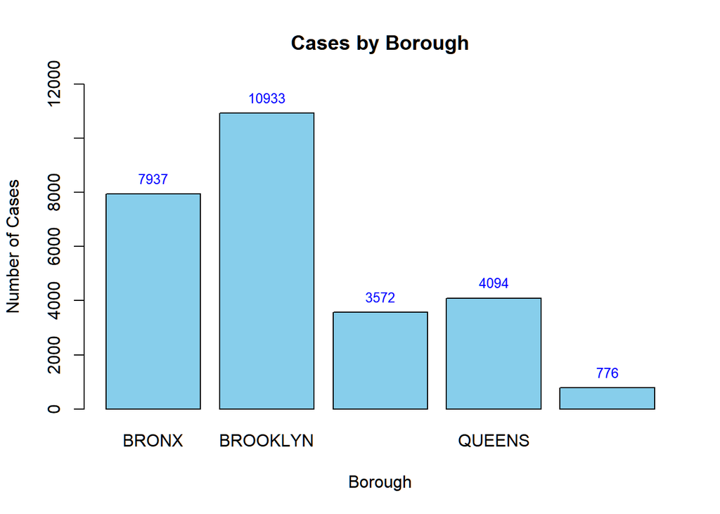

```r
boro_summary <- table(data$BORO)
# print(boro_summary)
bar <- barplot(boro_summary, main = "Cases by Borough", xlab = "Borough", ylab = "Number of Cases", col = "skyblue",ylim = c(0, 12000))
text(x = bar, y = boro_summary, labels = boro_summary, pos = 3, cex = 0.8, col = "blue")
```

Borough with Highest Cases: Brooklyn has the highest number of cases followed by Bronx.

#### 2. Monthly Cases and Trend

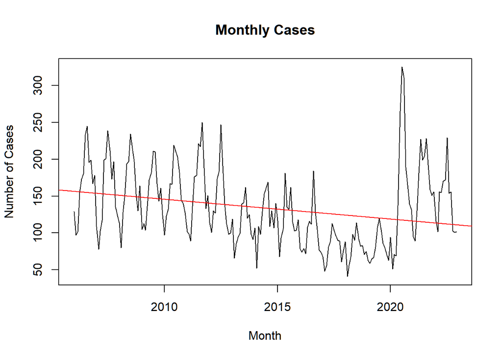

```r
data$YearMonth <- format(data$OCCUR_DATE, "%Y-%m")
monthly_cases <- table(data$YearMonth)
monthly_cases_df <- as.data.frame(table(data$YearMonth))
names(monthly_cases_df) <- c("YearMonth", "Count")
monthly_cases_df$YearMonth <- as.Date(paste(monthly_cases_df$YearMonth,"-01", sep=""), "%Y-%m-%d")
monthly_cases_df <- monthly_cases_df[order(monthly_cases_df$YearMonth), ]
plot(Count ~ YearMonth, data = monthly_cases_df, type = "l", main = "Monthly Cases", xlab = "Month", ylab = "Number of Cases")
model <- lm(Count ~ YearMonth, data = monthly_cases_df)
abline(model, col = "red")
```

Monthly cases chart shows the trend of crimes. It shows a decline trend until 2020. The cases number spikes when Covid pandemic started

```r
summary(data)
```

```
##   INCIDENT_KEY         OCCUR_DATE          OCCUR_TIME            BORO
##  Min.   :  9953245   Min.   :2006-01-01   Length:27312       Length:27312
##  1st Qu.: 63860880   1st Qu.:2009-07-18   Class :character   Class :character
##  Median : 90372218   Median :2013-04-29   Mode  :character   Mode  :character
##  Mean   :120860536   Mean   :2014-01-06
##  3rd Qu.:188810230   3rd Qu.:2018-10-15
##  Max.   :261190187   Max.   :2022-12-31
##
##  LOC_OF_OCCUR_DESC     PRECINCT      JURISDICTION_CODE LOC_CLASSFCTN_DESC
##  Length:27312       Min.   :  1.00   Min.   :0.0000    Length:27312
##  Class :character   1st Qu.: 44.00   1st Qu.:0.0000    Class :character
##  Mode  :character   Median : 68.00   Median :0.0000    Mode  :character
##                     Mean   : 65.64   Mean   :0.3269
##                     3rd Qu.: 81.00   3rd Qu.:0.0000
##                     Max.   :123.00   Max.   :2.0000
##                                      NA's   :2
##  LOCATION_DESC      STATISTICAL_MURDER_FLAG PERP_AGE_GROUP
##  Length:27312       Length:27312            Length:27312
##  Class :character   Class :character        Class :character
##  Mode  :character   Mode  :character        Mode  :character
##
##
##
##
##    PERP_SEX          PERP_RACE         VIC_AGE_GROUP        VIC_SEX
##  Length:27312       Length:27312       Length:27312       Length:27312
##  Class :character   Class :character   Class :character   Class :character
##  Mode  :character   Mode  :character   Mode  :character   Mode  :character
##
##
##
##
##    VIC_RACE           X_COORD_CD        Y_COORD_CD        Latitude
##  Length:27312       Min.   : 914928   Min.   :125757   Min.   :40.51
##  Class :character   1st Qu.:1000029   1st Qu.:182834   1st Qu.:40.67
##  Mode  :character   Median :1007731   Median :194487   Median :40.70
##                     Mean   :1009449   Mean   :208127   Mean   :40.74
##                     3rd Qu.:1016838   3rd Qu.:239518   3rd Qu.:40.82
##                     Max.   :1066815   Max.   :271128   Max.   :40.91
##                                                        NA's   :10
##    Longitude        Lon_Lat           YearMonth
##  Min.   :-74.25   Length:27312       Length:27312
##  1st Qu.:-73.94   Class :character   Class :character
##  Median :-73.92   Mode  :character   Mode  :character
##  Mean   :-73.91
##  3rd Qu.:-73.88
##  Max.   :-73.70
##  NA's   :10
```

#### 3.Crimes by Race

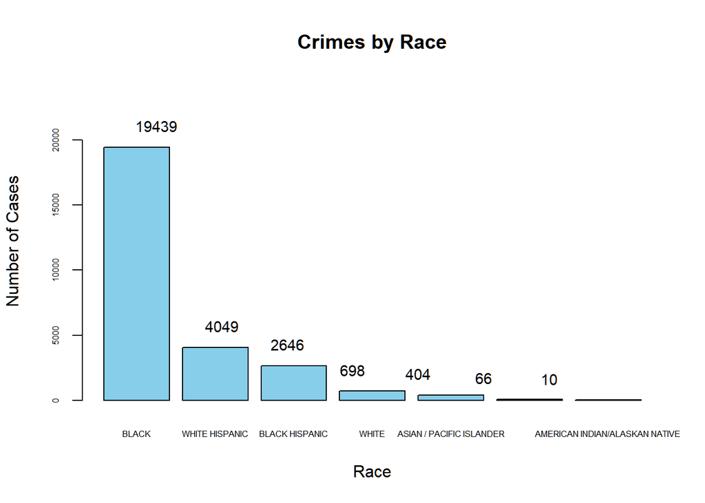

```r
# Summarize cases by race
race_summary <- table(data$VIC_RACE)

race_summary_sorted <- sort(race_summary, decreasing = TRUE)
max_y <- max(race_summary_sorted) + 5000
y_limit <- max(race_summary_sorted) * 1.10
barplot(race_summary_sorted, main = "Crimes by Race", xlab = "Race", ylab = "Number of Cases",
        col = "skyblue", las=0, ylim = c(0, max_y), cex.axis=0.5,cex.names = 0.5)
text(x = 1:length(race_summary_sorted), y = race_summary_sorted +(0.02 * y_limit),
     labels = race_summary_sorted, pos = 3, cex = 0.9)
```

#### 4.Crime Cases by Hour

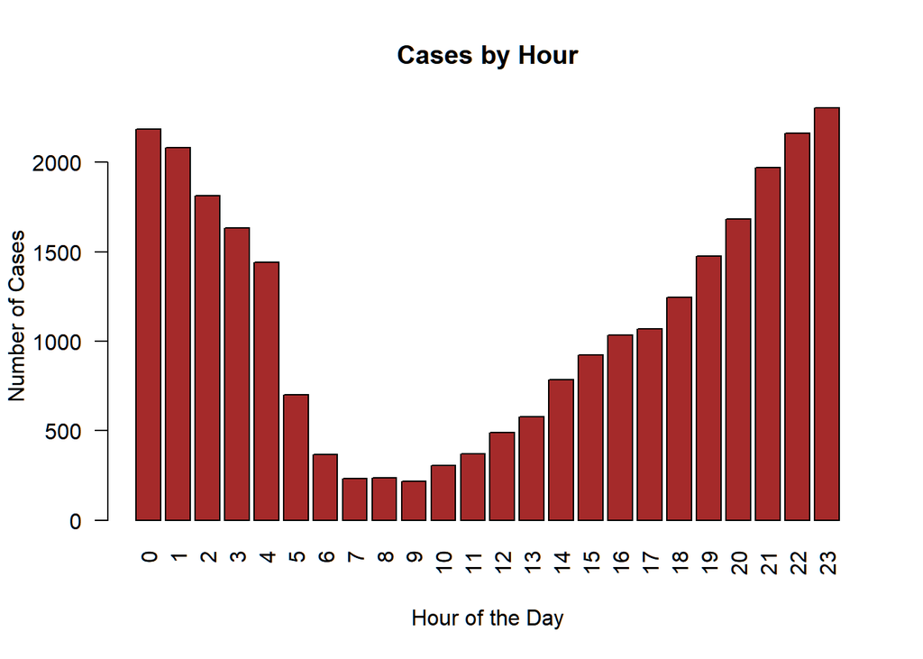

```r
# Extract hour from OCCUR_TIME and convert to numeric
data$hour <- as.numeric(substr(data$OCCUR_TIME, 1, 2))
hour_summary <- table(data$hour)

# Since the hours are already in numeric format, they should be sorted numerically
# However, to ensure correct order, we can explicitly sort them:
hour_summary_sorted <- hour_summary[order(as.numeric(names(hour_summary)))]

barplot(hour_summary_sorted, main = "Cases by Hour", xlab = "Hour of the Day", ylab = "Number of Cases",
        col = "brown", las=2)
```

It clearly shows the peak times when crimes are most frequently reported and the quiet times when there are fewer crimes.

```r
# install.packages("ggmap")
# install.packages("ggplot2")
# install.packages("treemap")
library(ggmap)
library(ggplot2)
```

#### 5.Crimes on Map to show which area in NYC has the highest crime density

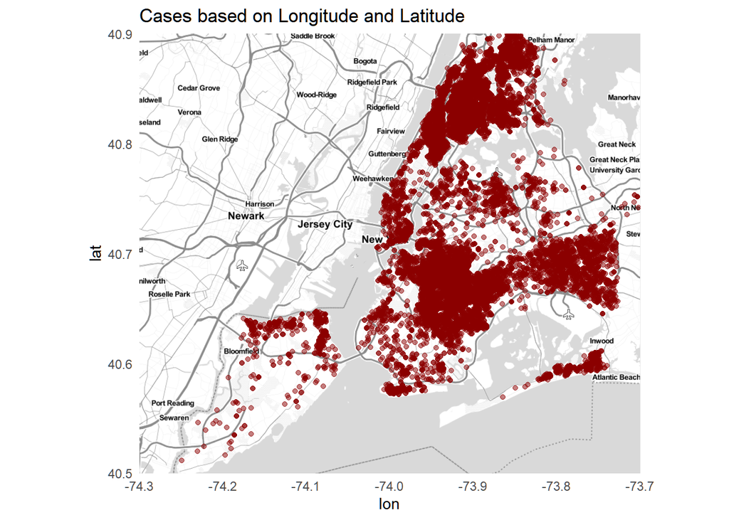

```r
nyc_map <- ggmap::get_stamenmap(bbox = c(left = -74.3, bottom = 40.5, right = -73.7, top = 40.9),
                                zoom = 11, maptype = "toner-lite")
ggmap(nyc_map) +
  geom_point(data = data, aes(x = Longitude, y = Latitude), color="darkred", alpha = 0.5) +
  theme_minimal() +
  labs(title = "Cases based on Longitude and Latitude")
```

#### 6.Crime by Age Group

```r
# Summarize cases by victim age group
age_group_summary <- table(data$VIC_AGE_GROUP)

# Remove any NA or empty age groups if present
age_group_summary <- age_group_summary[names(age_group_summary) != ""]
age_group_summary <- age_group_summary[!is.na(names(age_group_summary))]

age_group_summary
```

```
##
##     <18    1022   18-24   25-44   45-64     65+ UNKNOWN
##    2839       1   10086   12281    1863     181      61
```

The age group 25-44 has the highest number of crime cases. This could mean several things: perhaps this demographic is more exposed to certain types of environments or situations where these crimes are prevalent, or maybe certain crimes specifically target this age group more than others.

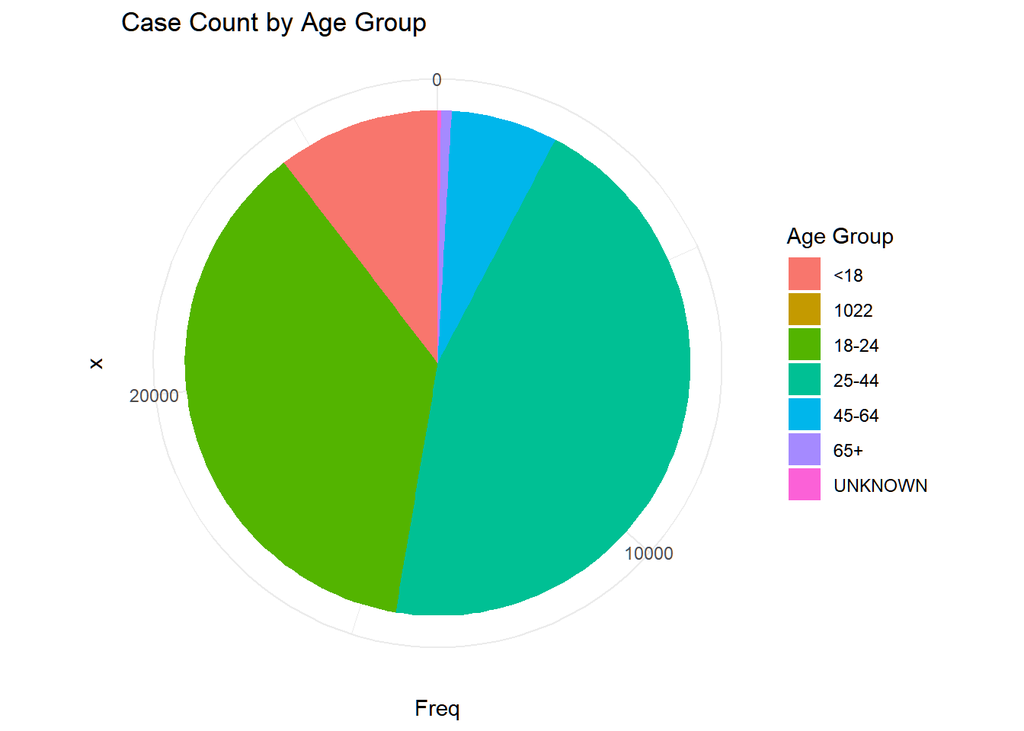

```r
#Pie Chart
age_group_summary <- as.data.frame(table(data$VIC_AGE_GROUP))
ggplot(age_group_summary, aes(x = "", y = Freq, fill = Var1)) +
  geom_bar(width = 1, stat = "identity") +
  coord_polar("y", start = 0) +
  labs(title = "Case Count by Age Group", fill = "Age Group") +
  theme_minimal()
```

```r
library(treemap)
```

#### 7. Crime by Location

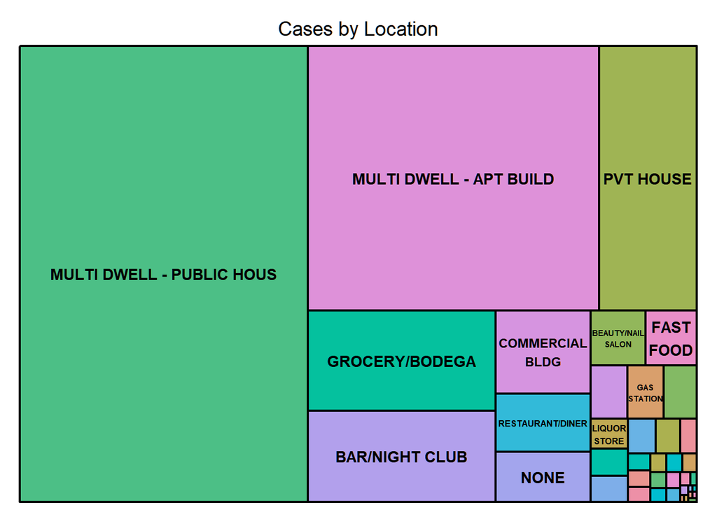

```r
location_summary <- data[!is.na(data$LOCATION_DESC) & data$LOCATION_DESC != "(null)" & data$LOCATION_DESC != "", ]
location_summary <- as.data.frame(table(location_summary$LOCATION_DESC))
location_summary <- location_summary[order(-location_summary$Freq),]
treemap(location_summary,
        index = "Var1",
        vSize = "Freq",
        title = "Cases by Location")
```

Residential areas, including public housing, private apartments, and private houses, seem to be the most common locations for crime based on this dataset. This could suggest that people might be at a higher risk within their living areas, pointing to a need for enhanced community policing or security measures in these zones.

Commercial and entertainment venues, like grocery stores, bars, and commercial buildings, also see a substantial number of incidents. Owners and patrons should be aware of potential risks and may consider enhancing security or surveillance.

```r
print(location_summary)
```

```
##                         Var1 Freq
## 25 MULTI DWELL - PUBLIC HOUS 4832
## 24   MULTI DWELL - APT BUILD 2835
## 28                 PVT HOUSE  951
## 17            GROCERY/BODEGA  694
## 3             BAR/NIGHT CLUB  628
## 9            COMMERCIAL BLDG  292
## 29          RESTAURANT/DINER  204
## 26                      NONE  175
## 4          BEAUTY/NAIL SALON  112
## 15                 FAST FOOD  104
## 33 SOCIAL CLUB/POLICY LOCATI   72
## 16               GAS STATION   71
## 19                  HOSPITAL   65
## 22              LIQUOR STORE   41
```

[output cut: 25 more lines]

### BIAS IDENTIFICATION

While commercial and public areas may seem logical crime hotspots due to high foot traffic, the data highlights residential areas as primary locations. This reminds us that crime permeates intimate spaces, not just public ones.

Given their association with late nights and rowdiness, one may expect bars and nightclubs to top the location list. However, they in fact rank below residential areas, suggesting we rethink our ideas of so-called “risky” places.

In a nutshell, interpreting crime statistics requires moving past assumptions and biases to develop a thoughtful, nuanced perspective. A probing analysis provides greater insight into this multi-layered issue.